# CENG 4515 DATA SCIENCE AND ANALYTICS HMW1

Fatma Karadağ

19/ 10 / 2021

I created the dataset myself, I wanted to create a dataset using the information about the artists and songs I liked in my spotify list and examine it.

# Importing the relevant libraries

```r
library(ggplot2)
library(dplyr)
library(GGally)
library(tidyverse)
library(readxl)
```

## importing dataset

```r
df <- read_excel("C:/Users/ftmak/OneDrive/Masaüstü/favouritesongs.xlsx")
```

```
## * `` -> ...1
```

# Let’s check the data

```r
head(df, n=3)
```

```
## # A tibble: 3 x 6
##    ...1 sanatci_adi    sarki_adi album_adi  sarkinin_cikis_tar~ sarkinin_dinlen~
##   <dbl> <chr>          <chr>     <chr>      <dttm>                         <dbl>
## 1     1 emir can igrek kor       single     2021-10-08 00:00:00          1200457
## 2     2 charlie puth   attention voicenotes 2018-09-03 00:00:00       1222456123
## 3     3 emir can igrek nalan     single     2019-09-06 00:00:00         62830200
```

With colnames(), all column names in the data set are printed on the screen.

```r
colnames(df)
```

```
## [1] "...1"                     "sanatci_adi"
## [3] "sarki_adi"                "album_adi"
## [5] "sarkinin_cikis_tarihi"    "sarkinin_dinlenme_sayisi"
```

I looked at the types of data contained in the dataset with typeof()

```r
x <- df
typeof(x)
```

```
## [1] "list"
```

```r
length(x)
```

```
## [1] 6
```

```r
colnames(x)
```

```
## [1] "...1"                     "sanatci_adi"
## [3] "sarki_adi"                "album_adi"
## [5] "sarkinin_cikis_tarihi"    "sarkinin_dinlenme_sayisi"
```

```r
summary(x)
```

```
##       ...1       sanatci_adi         sarki_adi          album_adi
##  Min.   : 1.00   Length:10          Length:10          Length:10
##  1st Qu.: 3.25   Class :character   Class :character   Class :character
##  Median : 5.50   Mode  :character   Mode  :character   Mode  :character
##  Mean   : 5.50
##  3rd Qu.: 7.75
##  Max.   :10.00
##  sarkinin_cikis_tarihi         sarkinin_dinlenme_sayisi
##  Min.   :2017-11-03 00:00:00   Min.   :5.008e+05
##  1st Qu.:2018-11-16 00:00:00   1st Qu.:2.338e+06
##  Median :2019-06-21 00:00:00   Median :1.834e+07
##  Mean   :2019-10-14 07:12:00   Mean   :2.248e+08
##  3rd Qu.:2020-11-25 00:00:00   3rd Qu.:5.436e+07
##  Max.   :2021-10-08 00:00:00   Max.   :1.222e+09
```

```r
sapply(df,class)
```

```
## $...1
## [1] "numeric"
##
## $sanatci_adi
## [1] "character"
##
## $sarki_adi
## [1] "character"
##
## $album_adi
## [1] "character"
##
## $sarkinin_cikis_tarihi
## [1] "POSIXct" "POSIXt"
##
## $sarkinin_dinlenme_sayisi
## [1] "numeric"
```

select() allows you to rapidly zoom in on a useful subset using operations based on the names of the variables.

```r
select(df,-(album_adi:sarkinin_cikis_tarihi))
```

```
## # A tibble: 10 x 4
##     ...1 sanatci_adi          sarki_adi          sarkinin_dinlenme_sayisi
##    <dbl> <chr>                <chr>                                 <dbl>
##  1     1 emir can igrek       kor                                 1200457
##  2     2 charlie puth         attention                        1222456123
##  3     3 emir can igrek       nalan                              62830200
##  4     4 dolu kadehi ters tut gitme                              23895123
##  5     5 aya nakamura         sans moi                            1123789
##  6     6 emir can igrek       zemin                               5751469
##  7     7 alec benjamin        let me down slowly                888789249
##  8     8 alec benjamin        swim                               28962149
##  9     9 dolu kadehi ters tut aldattim                           12789124
## 10    10 emir can igrek       ecza deposu                          500789
```

From these variables, I selected all the variables between the “sarki_adi” and “sarkinin_cikis_tarihi” and defined them as “s1”.

```r
s1 <- dplyr::select(df, sarki_adi:sarkinin_cikis_tarihi)
s1
```

```
## # A tibble: 10 x 3
##    sarki_adi          album_adi              sarkinin_cikis_tarihi
##    <chr>              <chr>                  <dttm>
##  1 kor                single                 2021-10-08 00:00:00
##  2 attention          voicenotes             2018-09-03 00:00:00
##  3 nalan              single                 2019-09-06 00:00:00
##  4 gitme              karanlik               2019-04-05 00:00:00
##  5 sans moi           single                 2021-07-07 00:00:00
##  6 zemin              single                 2021-02-13 00:00:00
##  7 let me down slowly narrated for you       2018-11-16 00:00:00
##  8 swim               narrated for you       2018-11-16 00:00:00
##  9 aldattim           dunyanın en iyi albumu 2017-11-03 00:00:00
## 10 ecza deposu        sapa                   2020-03-30 00:00:00
```

filter() allows you to subset observations based on their values. The first argument is the name of the data frame. The second and subsequent arguments are the expressions that filter the data frame.

```r
filter(df,sarki_adi=="attention",sanatci_adi=="charlie puth")
```

```
## # A tibble: 1 x 6
##    ...1 sanatci_adi  sarki_adi album_adi  sarkinin_cikis_tari~ sarkinin_dinlenm~
##   <dbl> <chr>        <chr>     <chr>      <dttm>                           <dbl>
## 1     2 charlie puth attention voicenotes 2018-09-03 00:00:00         1222456123
```

I returned the song information with the number of listens over 8000000 to the screen with the filter() method.

```r
filter(df,sarkinin_dinlenme_sayisi > 8000000)
```

```
## # A tibble: 6 x 6
##    ...1 sanatci_adi          sarki_adi album_adi sarkinin_cikis_tar~ sarkinin_dinlen~
##   <dbl> <chr>                <chr>     <chr>     <dttm>                         <dbl>
## 1     2 charlie puth         attention voicenot~ 2018-09-03 00:00:00       1222456123
## 2     3 emir can igrek       nalan     single    2019-09-06 00:00:00         62830200
## 3     4 dolu kadehi ters tut gitme     karanlik  2019-04-05 00:00:00         23895123
## 4     7 alec benjamin        let me d~ narrated~ 2018-11-16 00:00:00        888789249
## 5     8 alec benjamin        swim      narrated~ 2018-11-16 00:00:00         28962149
## 6     9 dolu kadehi ters tut aldattim  dunyanın~ 2017-11-03 00:00:00         12789124
```

arrange() works similarly to filter() except that instead of selecting rows, it changes their order.

For the songs in my data, I used both arrange() and desc() to reorder them by a column in descending order.

```r
arrange(df, desc(sarkinin_cikis_tarihi))
```

```
## # A tibble: 10 x 6
##     ...1 sanatci_adi  sarki_adi  album_adi  sarkinin_cikis_tar~ sarkinin_dinlen~
##    <dbl> <chr>        <chr>      <chr>      <dttm>                         <dbl>
##  1     1 emir can ig~ kor        single     2021-10-08 00:00:00          1200457
##  2     5 aya nakamura sans moi   single     2021-07-07 00:00:00          1123789
##  3     6 emir can ig~ zemin      single     2021-02-13 00:00:00          5751469
##  4    10 emir can ig~ ecza depo~ sapa       2020-03-30 00:00:00           500789
##  5     3 emir can ig~ nalan      single     2019-09-06 00:00:00         62830200
##  6     4 dolu kadehi~ gitme      karanlik   2019-04-05 00:00:00         23895123
##  7     7 alec benjam~ let me do~ narrated ~ 2018-11-16 00:00:00        888789249
##  8     8 alec benjam~ swim       narrated ~ 2018-11-16 00:00:00         28962149
##  9     2 charlie puth attention  voicenotes 2018-09-03 00:00:00       1222456123
## 10     9 dolu kadehi~ aldattim   dunyanın ~ 2017-11-03 00:00:00         12789124
```

Here, I got the columns I wanted with the select() method above, and now I sorted the columns I arranged using the arrange() method.

That is, I have also shown the method of using the select() and arrange() methods by combining them.

```r
arrange(s1, album_adi)
```

```
## # A tibble: 10 x 3
##    sarki_adi          album_adi              sarkinin_cikis_tarihi
##    <chr>              <chr>                  <dttm>
##  1 aldattim           dunyanın en iyi albumu 2017-11-03 00:00:00
##  2 gitme              karanlik               2019-04-05 00:00:00
##  3 let me down slowly narrated for you       2018-11-16 00:00:00
##  4 swim               narrated for you       2018-11-16 00:00:00
##  5 ecza deposu        sapa                   2020-03-30 00:00:00
##  6 kor                single                 2021-10-08 00:00:00
##  7 nalan              single                 2019-09-06 00:00:00
##  8 sans moi           single                 2021-07-07 00:00:00
##  9 zemin              single                 2021-02-13 00:00:00
## 10 attention          voicenotes             2018-09-03 00:00:00
```

# Data visualisation(example-1)

First, I visualized how many songs are from which album, and then I visualized how many songs each artist has from which album and blended my information.

```r
df$album_adi <- as.factor(df$album_adi)
summary(df$album_adi)
```

```
## dunyanın en iyi albumu               karanlik       narrated for you
##                      1                      1                      2
##                   sapa                 single             voicenotes
##                      1                      4                      1
```

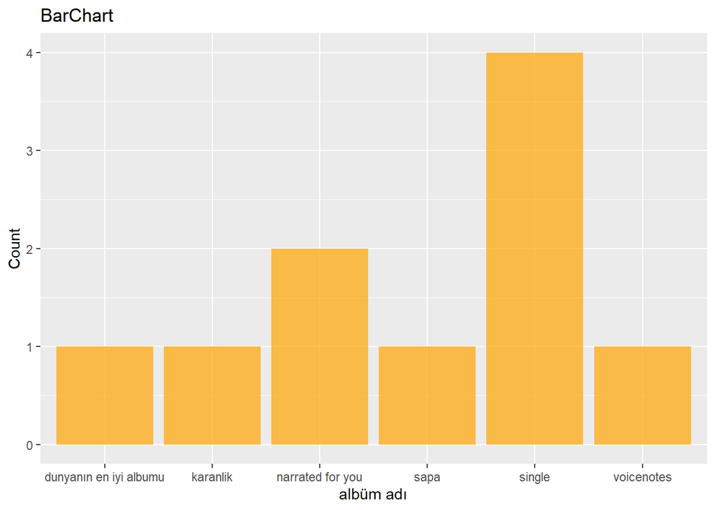

```r
ggplot(data=df, aes(x=album_adi)) +
  geom_bar(fill="orange", alpha=0.7)+
  labs(title = "BarChart", x="albüm adı", y="Count")
```

```r
df$sanatci_adi <- as.factor(df$sanatci_adi)
summary(df$sanatci_adi)
```

```
##        alec benjamin         aya nakamura         charlie puth
##                    2                    1                    1
## dolu kadehi ters tut       emir can igrek
##                    2                    4
```

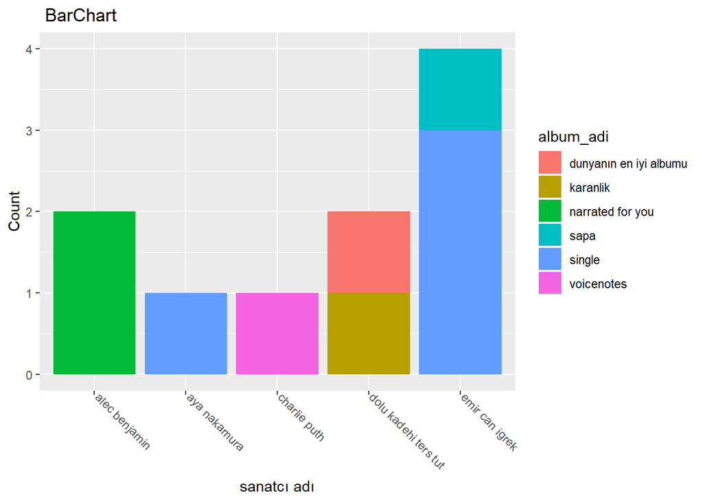

```r
ggplot(df, aes(x=sanatci_adi, fill=album_adi))+
  geom_bar() +
  labs(title = " BarChart",x= "sanatcı adı",y= "Count") +
  theme(axis.text.x=element_text(angle=-45,hjust=0,vjust=0))
```

As seen above, it is shown how many songs the artists have from which album. that is, these data can be found by looking at the bar chart.

# Data visualisation(example-2)

```r
df$sarkinin_cikis_tarihi <- as.Date(df$sarkinin_cikis_tarihi, "%m/%d/%Y")
df$age <- as.numeric(format(df$sarkinin_cikis_tarihi, "%Y"))

df$age <- 2021 - df$age

age.df <- data.frame(table(df$age))
names(age.df) <- c("age", "freq")
age.df
```

```
##   age freq
## 1   0    3
## 2   1    1
## 3   2    2
## 4   3    3
## 5   4    1
```

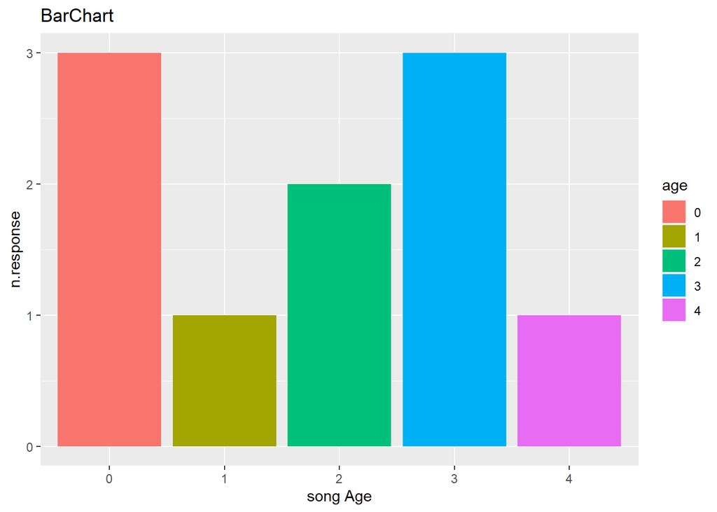

```r
ggplot(age.df, aes(x=age, y=freq, fill=age))+
  geom_bar(stat = "identity") +
  labs(title = "BarChart", x="song Age", y="n.response")
```

I calculated the ages of the songs by looking at their release dates and showed them how many songs were of the same age. The value shown as 0 is equivalent to 2021, so the age of the song is zero. In the 1st one, it belongs to 2020 and is 1 year old, I created a logic in this way.

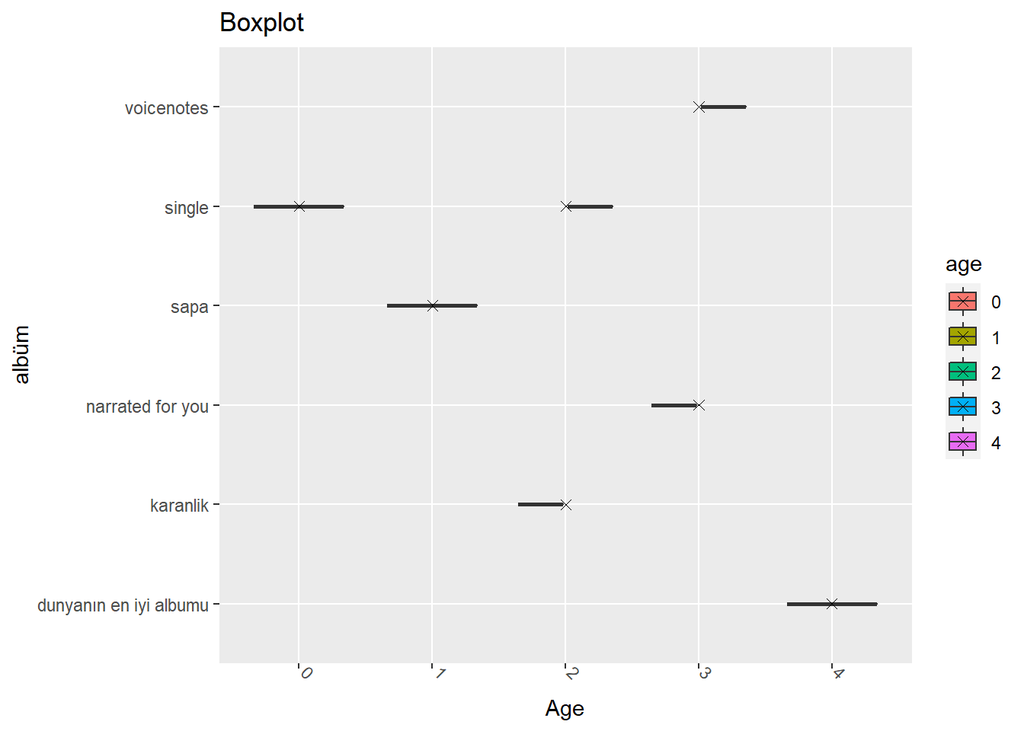

```r
df$age <- as.factor(df$age)
ggplot(data=df, aes(x=age, y=album_adi, fill= age)) +
  geom_boxplot() +
  labs(title = "Boxplot", x="Age", y="albüm") +
  stat_summary(fun=mean, geom="point", shape=4, size=2) +
  theme(axis.text.x=element_text(angle=-45,hjust=0,vjust=0))
```

Here too, the ages of the albums they are on are calculated in line with the release dates of the songs.